# Interesting Demographics and Visualizations for Philadelphia and UCD

Samriddhi Khare

2023-10-19

## Introduction

A general Philadelphia’s demographics has been the growth and diversification of its population. Philadelphia experienced a population increase, reversing the trend of population decline seen in previous decades. This growth was partially attributed to an influx of younger residents and an increase in the number of students in the city’s universities. However, this has also led to gentrification.

Gentrification in the University City District of Philadelphia has been a prominent and complex issue in recent years. This neighborhood, home to institutions like the University of Pennsylvania and Drexel University, has experienced a significant transformation. As these universities have expanded and attracted more students and faculty, it has led to rising property values, increased rental costs, and a changing demographic landscape.

This report outlines specific demographic data and changes to highlight changes that have occurred in the recent years.

## R Setup and Packages

This code chunk deals with the necessary steps of loading packages that are used later in the script.

```r
library(tidyverse)
library(tidycensus)
library(sf)
library(kableExtra)
library(gridExtra)
library(tidyr)
library(ggplot2)
library(viridis)
library(stringr)
library(socviz)
library(extrafont)
library(gridtext)
library(grid)

source("helper_functions.R")
source("theme/theme_swd.R")

census_api_key('bf2d507651b5a621dbadd44533fb4f3deaab26bf')

options(scipen=999)
options(tigris_class = "sf")
```

## Creating a theme

The first step is to create a theme to ensure plots look neat and consistent.

```r
theme_sk <- function(base_size = 12, title_size = 16) {
  font <- "sans"

  # Create a base theme
  base_theme <- theme_minimal() +
    theme(
      panel.grid.minor = element_blank(),
      axis.ticks = element_blank(),
      axis.title = element_text(family = font, size = 12),
      plot.title = element_text(family = font, size = title_size, color = "black"),
   #   panel.border = element_rect(colour = "grey80", fill = NA, size = 1),
     # plot.background = element_blank(),
      text = element_text(family = font, color = "black"),
      strip.text = element_text(family = font, size = 12),
      strip.background = element_rect(fill = "grey80", color = "white"),
      axis.text = element_text(family = font, size = 10),
      plot.caption = element_text(family = font, hjust = 1),
      panel.grid.major = element_line(colour = "grey80", linetype = "longdash", size = 0.1),
      plot.subtitle = element_text(family = font, color = "grey50"),
      panel.background = element_blank()
    )

}
```

## Preparing the Data

To understand the changing demographics of Philadelphia and University City, we are going to use American Community Survey Census Data.

### Loading the Data

To load the data we will be using the Census api key and `get_acs` function, part of the `tidycensus` package. To study the citywide trends of gentrification, we will be looking at some variables such as median household income, number of residents with a graduate degree and some racial compositions.

```r
acs_variable_list <- load_variables(2020, #year
                                         "acs5", #five year ACS estimates
                                         cache = TRUE)

acs_vars <- c("B01001_001E", # ACS total Pop estimate
              "B25002_001E", # Estimate of total housing units
              "B25002_003E", # Number of vacant housing units
              "B19013_001E", # Median HH Income ($)
              "B02001_002E", # People describing themselves as "white alone"
              "B06009_006E") # Total graduate or professional degree

acsTractsPHL.2020 <- get_acs(geography = "tract",
                             year = 2020,
                             variables = acs_vars,
                             geometry = FALSE,
                             state = "PA",
                             county = "Philadelphia",
                             output = "wide") %>%
  dplyr::select (GEOID, NAME, all_of(acs_vars)) %>%
  rename (total_pop.2020 = B01001_001E,
          total_HU.2020 = B25002_001E,
          total_vacant.2020 = B25002_003E,
          med_HH_Income.2020 = B19013_001E,
          total_White.2020 = B02001_002E,
          total_GradDeg.2020 = B06009_006E) %>%
  mutate(vacancyPct.2020 = total_vacant.2020/total_HU.2020,
         pctWhite.2020 = total_White.2020/total_pop.2020,
         year = "2020")

acsTractsPHL.2016 <- get_acs(geography = "tract",
                             year = 2016,
                             variables = acs_vars,
                             geometry = FALSE,
                             state = "PA",
                             county = "Philadelphia",
                             output = "wide") %>%
  dplyr::select (GEOID, NAME, all_of(acs_vars)) %>%
  rename (total_pop.2016 = B01001_001E,
          total_HU.2016 = B25002_001E,
          total_vacant.2016 = B25002_003E,
          med_HH_Income.2016 = B19013_001E,
          total_White.2016 = B02001_002E,
          total_GradDeg.2016 = B06009_006E) %>%
  mutate(vacancyPct.2016 = total_vacant.2016/total_HU.2016,
         pctWhite.2016 = total_White.2016/total_pop.2016,
         year = "2020")

years <- 2012:2019
names(years) <- years

philly_value <- map_dfr(years, ~{
  get_acs(
    geography = "county",
    variables = "B01001B_001",
    state = "PA",
    county = "Philadelphia",
    year = .x,
    survey = "acs1"
  )
}, .id = "year") %>%
  mutate ( max = estimate + moe, min = estimate - moe)
```

### Wrangling

To assist the visualizations, we will define some central tendencies (mean and medians) and benchmark values (poverty line). We also separate the focus census tracts within University City District.

```r
#allACS <- full_join(acsTractsPHL.2016, acsTractsPHL.2020,
                  #  by= c("GEOID"))

#allACS <- na.omit(allACS)

# making data for UCD

myTracts <- c("42101036901",
              "42101036902",
              "42101008801",
              "42101008802",
              "42101036900")

acsTractsPHL.2016 <- acsTractsPHL.2016 %>%
  mutate(UCD = ifelse(GEOID %in% myTracts, "University City", "Philadelphia"))

acsTractsPHL.2020 <- acsTractsPHL.2020 %>%
  mutate(UCD = ifelse(GEOID %in% myTracts, "University City", "Philadelphia"))


avg_inc_16 <- mean(as.numeric(acsTractsPHL.2016$med_HH_Income.2016), na.rm = TRUE)
avg_inc_20 <- mean(as.numeric(acsTractsPHL.2020$med_HH_Income.2020), na.rm = TRUE)

avg_grad_16 <- mean(as.numeric(acsTractsPHL.2016$total_GradDeg.2016), na.rm = TRUE)
avg_grad_20 <- mean(as.numeric(acsTractsPHL.2020$total_GradDeg.2020), na.rm = TRUE)

min_inc <- 33000
```

## Visualizations

The three visualizations illustrate the demographic changes within Philadelphia and University City District.

### One

Main Insight: Between 2016 and 2020, the number of census tracts with median incomes above the poverty level have increased.

Tools Used: I used the preattentive attributes of hue or color to draw attention to the poverty line. I used similarity from the gestalt principles (the line for poverty benchmark and the ticks on the x and y axis are both longdashes) The subtitle is in a lighter grey to create a visual hierarchy and get the reader to pay more attention to the title.

I was unable to neatly arrange the histograms next to each other, and I think a side by side comparison would have been easier to read. I tried using `gridExtra` and `facetwrap`, but was unable to get satisfactory results.

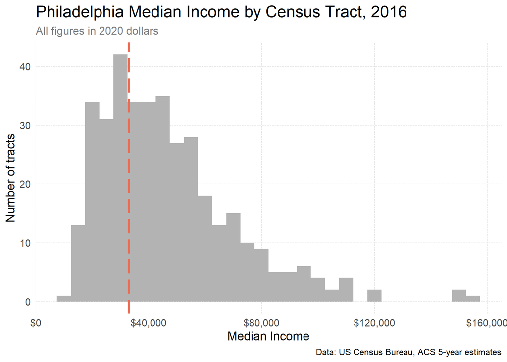

```r
ggplot(acsTractsPHL.2016)+
  geom_histogram(aes(med_HH_Income.2016*1.08),
                 binwidth = 5000, fill = "grey70")+
  labs(
    title = "Philadelphia Median Income by Census Tract, 2016",
     subtitle = "All figures in 2020 dollars",
    caption = "Data: US Census Bureau, ACS 5-year estimates",
    x="Median Income",
       y="Number of tracts")+
   geom_vline(xintercept = 33000, linetype = "longdash", col = "coral2", size=1)+
    scale_x_continuous(labels = scales::dollar_format())+
  theme_sk()+theme(
    plot.title = element_text(vjust = 1) ,
    plot.subtitle = element_text(vjust = 1)
  )
```

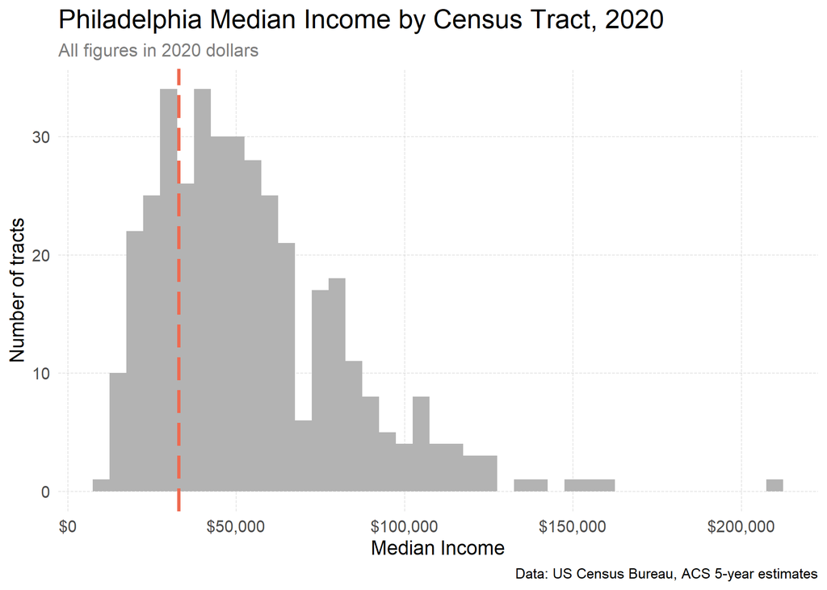

```r
ggplot(acsTractsPHL.2020)+
  geom_histogram(aes(med_HH_Income.2020),
                 binwidth = 5000, fill = "grey70")+
  labs(
   title = "Philadelphia Median Income by Census Tract, 2020",
     subtitle = "All figures in 2020 dollars",
    caption = "Data: US Census Bureau, ACS 5-year estimates",
    x="Median Income",
       y="Number of tracts")+
   geom_vline(xintercept = 33000, linetype = "longdash", col = "coral2", size=1)+
    scale_x_continuous(labels = scales::dollar_format())+
  theme_sk()
```

### Two

Main Insight: The number of graduate degree holders in University City District has increased in the last five years, when compared to the average number of graduate degree holders per census tract.

Tools Used: This plot also makes use of the previous preattentive attribute of hue to bring attention to the UCD tracts specifically. The color `coral2` is used to keep the graphs consistent with the accent color of the markdown theme. The gestalt principle of enclosure is used here to create 4 distinct quadrants on the graphs using lines similar to the ticks but darker in color. The point of intersection of the average also creates a focus towards the central tendencies of both variables.

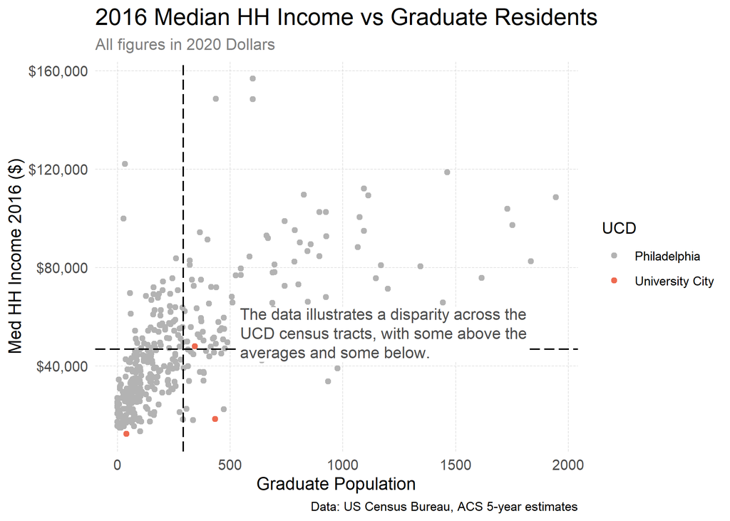

[figure not shown]

```r
grob_explanation <- grobTree(richtext_grob(
  "<span style='background-color:white'>The data illustrates a disparity across the<br>UCD census tracts, with some above the<br>averages and some below.</span>",
  x=.3,  y=0.3, hjust=0, gp=gpar(col = "grey30", fontsize=11), box_gp = gpar(col = "white", fill = "white"),
  padding = margin(0,0,0,0,"in")))

ggplot(acsTractsPHL.2016) +
  geom_point(aes(
    x =total_GradDeg.2016 ,
    y = med_HH_Income.2016*1.08,
    color = UCD
  )) +
  geom_hline(yintercept = avg_inc_16*1.08, linetype = "longdash", linewidth = 0.5, color = "black") +
  geom_vline(xintercept = avg_grad_16, linetype = "longdash", linewidth = 0.5, color = "black") +
  labs(
    title = "2016 Median HH Income vs Graduate Residents",
    subtitle = "All figures in 2020 Dollars",
    caption = "Data: US Census Bureau, ACS 5-year estimates",
   x = "Graduate Population",
   y = "Med HH Income 2016 ($)"
  ) +
  annotation_custom(grob_explanation) +
    scale_y_continuous(labels = scales::dollar_format()) +
  #scale_x_continuous(labels = scales::comma) +
  theme_sk() +
 #  geom_label(x = avg_grad_16, y = avg_inc_16, label = "AVG", hjust = 1.25, label.size = 0)
  scale_color_manual(
    values = c("University City" = "coral2", "Philadelphia" = "grey70")  )
```

### Three

Main Insight: The number of residents of Philadelphia identifying as “Black Alone” has been witnessing a decline in the recent years.

Tools Used: The gestalt principle of enclosure is used to set the margin of error, displaying that the value of the estimate with the bounds. The two points at the first and last values helps highlight the change using the preattentive principle of size.

[figure not shown]

```r
grob_explanation <- grobTree(richtext_grob(
  "<span style='background-color:white'>We can see there has been a decline<br>in the number of Black residents in<br>Philadelphia.</span>",
  x=0.1,  y=0.1, hjust=0, gp=gpar(col = "grey30", fontsize=11), box_gp = gpar(col = "transparent", fill = "transparent"),
  padding = margin(0,0,0,0,"in")))

pt <- ggplot(philly_value, aes(x = year, y = estimate, group = 1)) +
  geom_ribbon(aes(ymax = max, ymin = min), fill = "coral2", alpha = 0.4) +
  geom_line(size = 0.8, color = "coral2")+
  geom_point(size = 2, data = philly_value %>% slice(1), color = "coral2") +
  geom_point(size = 2, data = philly_value %>% slice(n()), color = "coral2") +
  geom_vline(xintercept = "2009", linetype = "dotted", size = 1, color = "black") +
 # geom_text(data = philly_value %>% filter(year >= 2009), label = estimate, nudge_y = 15, size = 2) +
  scale_y_continuous(labels= scales::comma) +
  labs(y ="Residents", x = NULL, title = "Philadelphia Residents that Identify as Black Alone", subtitle = "Shaded region represents Margin of Error", caption = "Data: US Census Bureau, ACS 5-year estimates") +
  annotation_custom(grob_explanation) + theme_sk()

pt %>%
  save_and_show_plot(width = 6, height = 4, "FIG0209.png")
```

## Conclusion and Github Repository

If I had more time I would include more graphs to further illustrate the relationship between demographic shifts and gentrification with more information on UCD. The github repository with all necessary data is located [here.](https://github.com/samriddhikhar3/MUSA_6951_Assignment3.git)

Looking forward to your feedback!